# Eficiencia en cuanto a desempeños fiscal, resultado del ICFES y población

Autor/a

Anderson Bedoya Ciro

Fecha de publicación

7 de abril de 2024

# Contexto

El presente trabajo, titulado “Eficiencia en cuanto a desempeños fiscal, resultado del ICFES y población,” aborda un análisis exhaustivo de diversos indicadores clave relacionados con los departamentos de Colombia. El objetivo principal es explorar las interconexiones entre el desempeño fiscal de los departamentos, los resultados obtenidos en las pruebas del ICFES, y la composición demográfica de la población.

## Croquis de los departamentos de Colombia

Se muestra el croquis del mapa de los departamentos de colombia que se va a usar para el análisis.

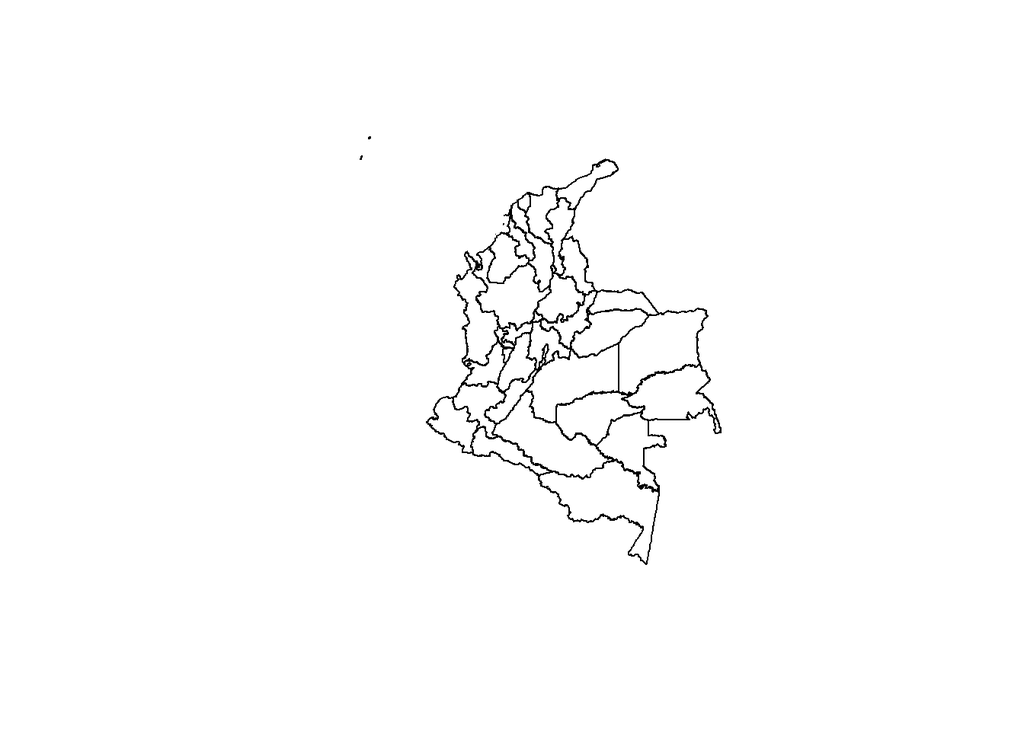

El croquis anterior muestra los departamentos de Colombia.

## Relación del tipo de colegio y los resultados del ICFES.

A continuación se meustra la relación que se tiene entre el puntaje promedio del ICFES por departamento y el porcentaje de colegios mixtos en cada departamento.

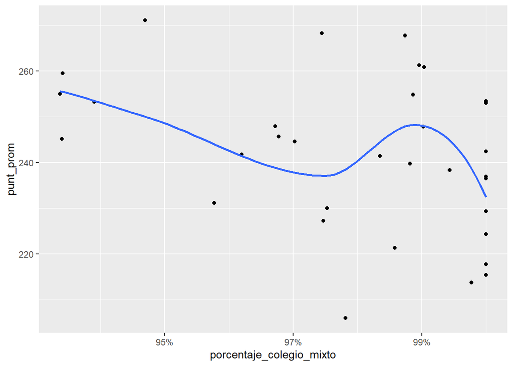

Como podemos ver en el gráfico anterior hay una leve tendencia a que los departamentos con mayor porcentaje de colegios mixtos tengan un menor puntaje promedio en el ICFES. Sin embargo, esta relación no es muy fuerte.

## Resultados de la calificación fiscal y los resultados del ICFES.

A continuación se muestra la relación que se tiene entre el puntaje promedio del ICFES por departamento y el resultado de la calificación fiscal con el indicador “Promedio Calificación Resultados” de cada departamento.

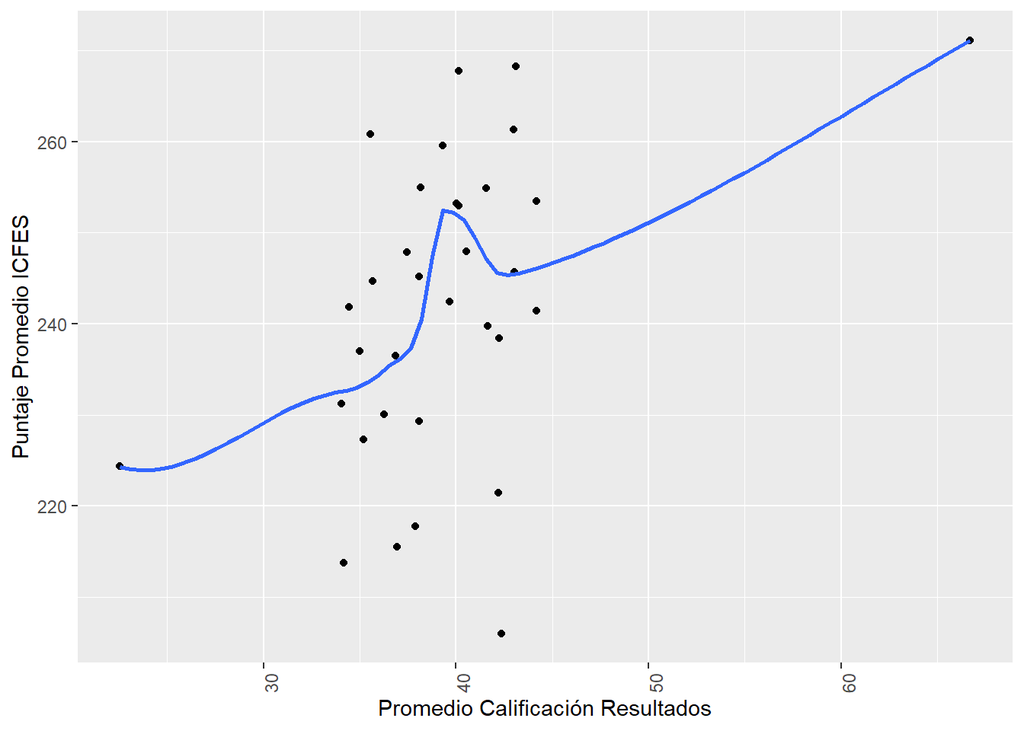

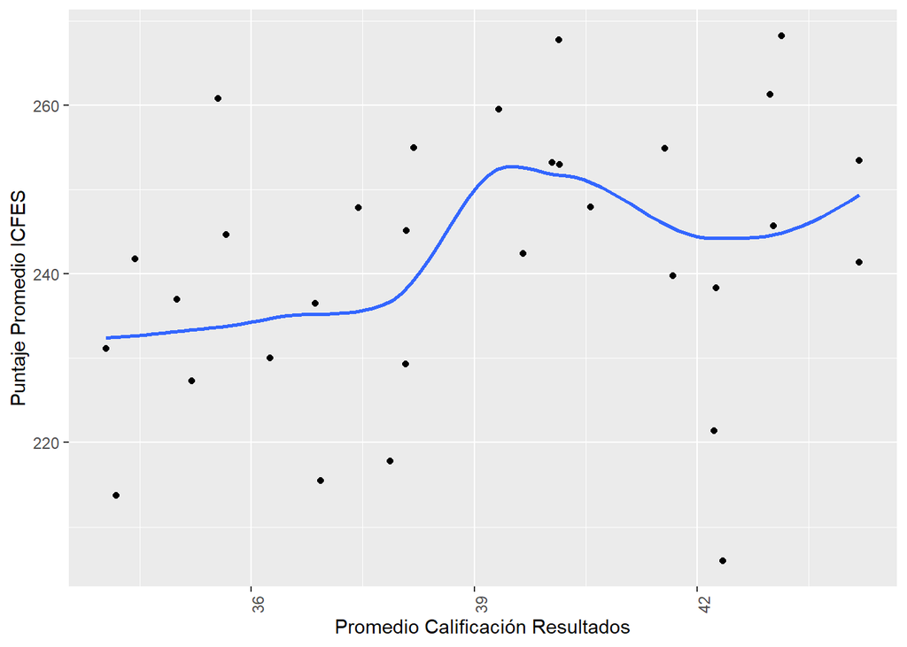

Cuando no se tienen en cuenta los departamentos de Bogotá y Guainía, la relación entre el puntaje promedio del ICFES y el resultado de la calificación fiscal se hace más débil, aunque sigue siendo positiva.

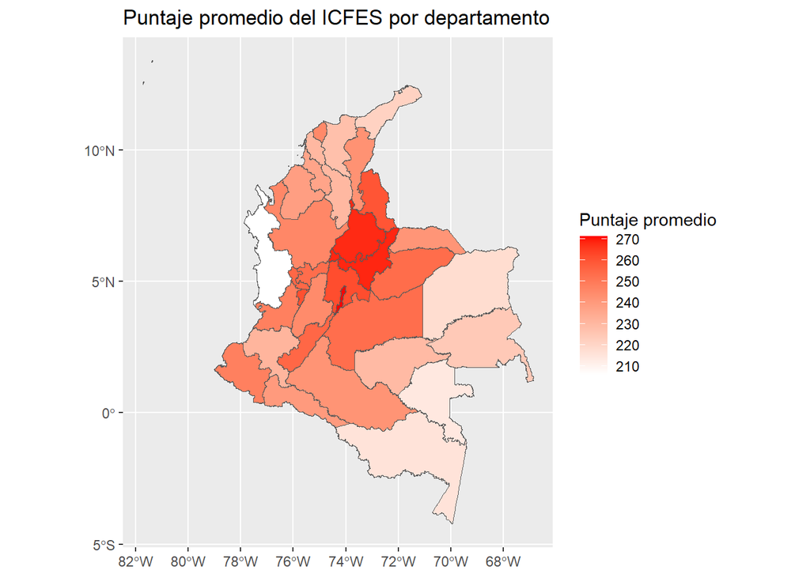

En el mapa se observa que el departamento con el puntaje promedio más alto es Bogotá, seguido de Boyacá, siendo Chocó el departamento con el puntaje promedio más bajo.

## Distribución del índice de eficiencia.

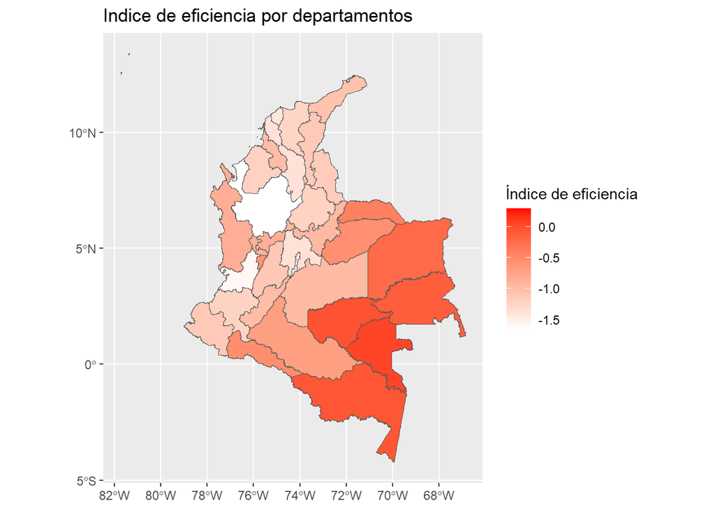

En logaritmo se puede notar aquí el indice de eficiencia de los departamentos graficados con el Promedio de Calificación de Resultados, el Puntaje Promedio del ICFES y el porcentaje de colegios mixtos.

## Listado de los departamentos con más alto índice de eficiencia.

| Departamento | punt_prom | prom_calif_resultados | porcentaje_colegio_mixto | Total_15-19 | log_indice_eficiencia_col_mix |
| --- | --- | --- | --- | --- | --- |
| SAN ANDRES | 236.97 | 35.00 | 1.00 | 4225 | 0.29 |
| VAUPES | 213.76 | 34.19 | 1.00 | 6461 | 0.05 |
| GUAVIARE | 229.32 | 38.07 | 1.00 | 9461 | -0.03 |
| AMAZONAS | 215.46 | 36.94 | 1.00 | 9309 | -0.07 |
| GUAINIA | 224.38 | 22.55 | 1.00 | 6749 | -0.13 |
| VICHADA | 217.76 | 37.87 | 1.00 | 13688 | -0.22 |
| ARAUCA | 241.40 | 44.17 | 0.98 | 26766 | -0.41 |
| PUTUMAYO | 239.75 | 41.67 | 0.99 | 34308 | -0.54 |
| CASANARE | 253.44 | 44.18 | 1.00 | 39330 | -0.55 |
| QUINDIO | 260.83 | 35.56 | 0.99 | 36139 | -0.59 |
| CAQUETA | 241.80 | 34.44 | 0.96 | 40030 | -0.70 |
| CHOCO | 206.01 | 42.34 | 0.98 | 60459 | -0.85 |
| CALDAS | 253.24 | 40.05 | 0.94 | 69584 | -0.86 |
| RISARALDA | 254.99 | 38.19 | 0.93 | 66652 | -0.87 |
| BOYACA | 268.24 | 43.13 | 0.97 | 101193 | -0.95 |
| META | 252.99 | 40.14 | 1.00 | 93722 | -0.97 |
| HUILA | 254.86 | 41.57 | 0.99 | 101560 | -0.99 |
| SUCRE | 236.51 | 36.86 | 1.00 | 86908 | -1.00 |
| GUAJIRA | 221.40 | 42.22 | 0.99 | 102606 | -1.05 |
| TOLIMA | 244.64 | 35.67 | 0.97 | 107615 | -1.10 |

Aquí se puede notar que los departamentos con mayor índice de eficiencia son los departamentos de San Andrés, Vaupés, Guaviare y Amazonas.

# Conclusiones

Como se ha podido evidenciar hay una relación entre el puntaje promedio del ICFES y el resultado de la calificación fiscal de forma positiva. Sin embargo, esta relación no es muy fuerte. Por otro lado, se puede observar que los departamentos con mayor índice de eficiencia son los departamentos de San Andrés, Vaupés, Guaviare y Amazonas. Estos indicadores pueden ser útiles para que el gobierno pueda tomar decisiones sobre la distribución de recursos para la educación en los diferentes departamentos.

# Referencias

Instituto Colombiano para la Evaluación de la Educación - Icfes. (marzo de 2024). DataIcfes: Repositorio de Datos Abiertos del Icfes. 04.Saber11 [Conjunto de datos]. Recuperado de https://www.icfes.gov.co/data-icfes

Centro de datos geoespaciales - CSCD (marzo de 2024). Departamento Político de Colombia [Datos geoespaciales]. Recuperado de https://csdc.immap.org/layers/geonode:MGN_DPTO_POLITICO

Departamento Administrativo Nacional de Estadística - DANE (s.f.). Proyecciones de Población. Recuperado de https://www.dane.gov.co/index.php/estadisticas-por-tema/demografia-y-poblacion/proyecciones-de-poblacion